# Hierarchical GAM on fish population trends in Bayesian framework

Model we are attempting to build:

$$N_{i,t} = f(t, \alpha_i) + g(\lambda_i,
\beta_i) + \varepsilon_i$$

Where:

- $N$ : population size estimate
- $i$ : population
- $t$ : time step
- $f(t, \alpha_i)$ : function estimating the temporal trend in population size
  - $\alpha$: estimated parameter describing each population’s temporal slope
- $g(\lambda, \beta_i)$ : function estimating latent variation in population size
  - $\lambda$ : latent variable (to capture covariation between populations)
  - $\beta$ : estimated parameter describing each population’s latent variation
- $\varepsilon$: residual variation

Because the model also estimates latent variation, we are accounting for the covariation between populations when estimating $N$.

This model then contains key information to calculate and extend an index like the Living Planet Index, to show the average change in population size from a baseline value of 1 in the start year.

The first part of the model estimates the temporal trend of each population’s size ($\alpha_i$), which contains information about population-level change *and* community-level change:

$$\alpha_i \sim N(\mu_{\alpha},
\sigma^2_{\alpha})$$

To calculate the index of change from a baseline of 1 (as in the LPI), the average population trend can then be plugged in to the LPI calculation as follows:

$$I_t = {\mu_{\alpha}}*t + 1$$

This trend can then be visualized and communicated with its known ($\sigma^2_{\alpha}$).

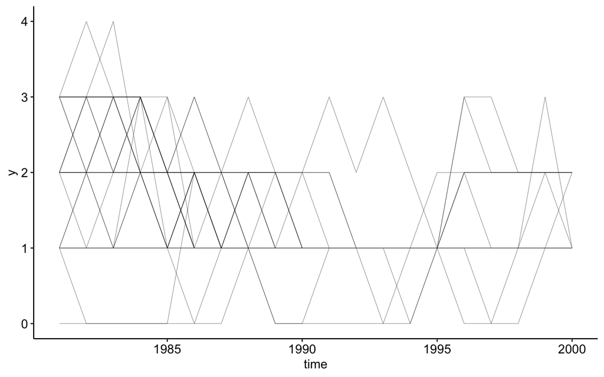

```r
#### import & set up data ####

# from https://github.com/eric-pedersen/groundfish-data-analysis
# note: these are mean biomasses over the whole sampled area with an SE
# not actually raw abundances. But for this purpose, should be ok
load("~/Documents/GitHub/groundfish-data-analysis/data/year_geom_means.Rdata")

year = rownames(Year_Geom_Means_all) %>% as.numeric()

# scale all columns
Year_Geom_Means_all = apply(Year_Geom_Means_all, 2, scale, center = FALSE) %>%
  as.data.frame()
Year_Geom_Means_all$time = year
df = Year_Geom_Means_all %>%
  pivot_longer(cols = -time,
               names_to = "series",
               values_to = "y")
df$series <- factor(df$series)
df$y <- ceiling(df$y)

# get number of populations & length of time series
npops <- ncol(Year_Geom_Means_all)
tsl <- nrow(Year_Geom_Means_all)

set.seed(2)
# dat <- sim_mvgam(T = 30,
#                  n_series = 20,
#                  n_lv = 1,
#                  family = 'poisson',
#                  mu_obs = runif(6, 4, 8),
#                  trend_rel = 0.6,
#                  train_prop = 0.85)
dat_train = filter(df, time %in% c(1981:2000))
dat_test = filter(df, time %in% c(2001:2013))

ggplot(dat_train) +
  geom_line(aes(x = time, y = y, group = series), lwd = .1)
```

## Building the model

```r
mod1 <- mvgam(data = dat_train,
                newdata = dat_test,
                formula = y ~ s(time, bs = "tp") + s(series, bs = 're'),
                use_lv = TRUE,
                n_lv = 1,
                family = 'poisson',
                trend_model = 'AR1',
                use_stan = TRUE,
                chains = 4,
                burnin = 300,
                samples = 400)
```

[figure not shown]

```r
plot(mod1)
```

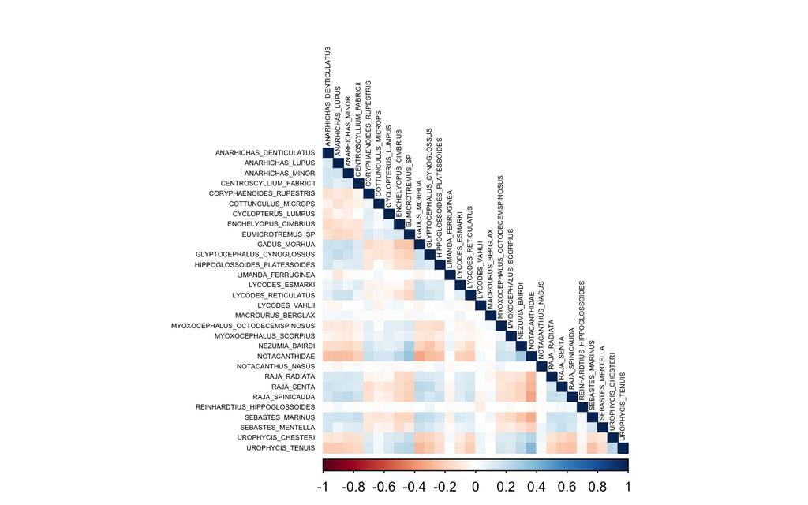

```r
sp_correlations = lv_correlations(mod1)

# Plot as heatmap
corrplot::corrplot(sp_correlations$mean_correlations,
                   type = "lower",
                   method = "color",
                   tl.cex = .4, tl.col = "black")
```